# Comparando mecanismos para jukebox sociais - Lab 4.3 - FPCC2

Nisston Moraes Tavares de Melo - Matrícula: 0120015808-15D

18 de junho de 2020

```r
dados = read_csv(here::here("data/satisfacoes.csv"),
                 col_types = "cdcc")

glimpse(dados)
```

```
## Observations: 115
## Variables: 4
## $ user_id      <chr> "1", "2", "3", "4", "5", "6", "7", "8", "9", "10", "11...
## $ satisfaction <dbl> 2.0, 3.0, 1.5, 1.0, 2.0, 2.5, 2.0, 3.0, 2.0, 2.0, 2.0,...
## $ scenario     <chr> "baseline", "baseline", "baseline", "baseline", "basel...
## $ group        <chr> "3", "1", "2", "2", "1", "1", "3", "3", "2", "1", "3",...
```

```
## [1] 1.521739
```

```
## [1] 0.08695652
```

[figure not shown]

```
## [1] 0
```

# Análise preliminar dos dados

Inicialmente vamos construir uma representação gráfica dos mecanismos e suas respectivas votações dentro de um histograma.

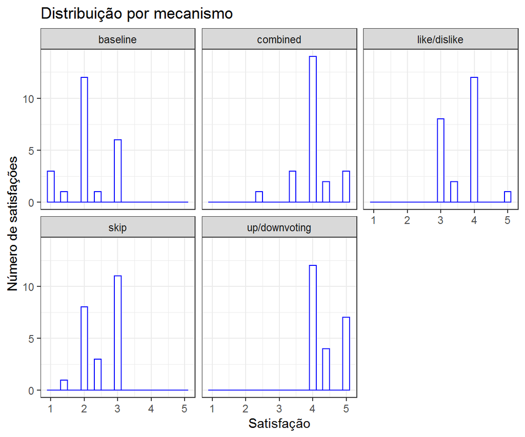

É possível verificar pela distribuição das frequência da satisfação entre os mecanimos vemos que existem dois em destaque: o up/downvoting e combined. Também é possível verificar que o up/downvoting é o que apresenta a maior quantidade de satisfações de nível 5.

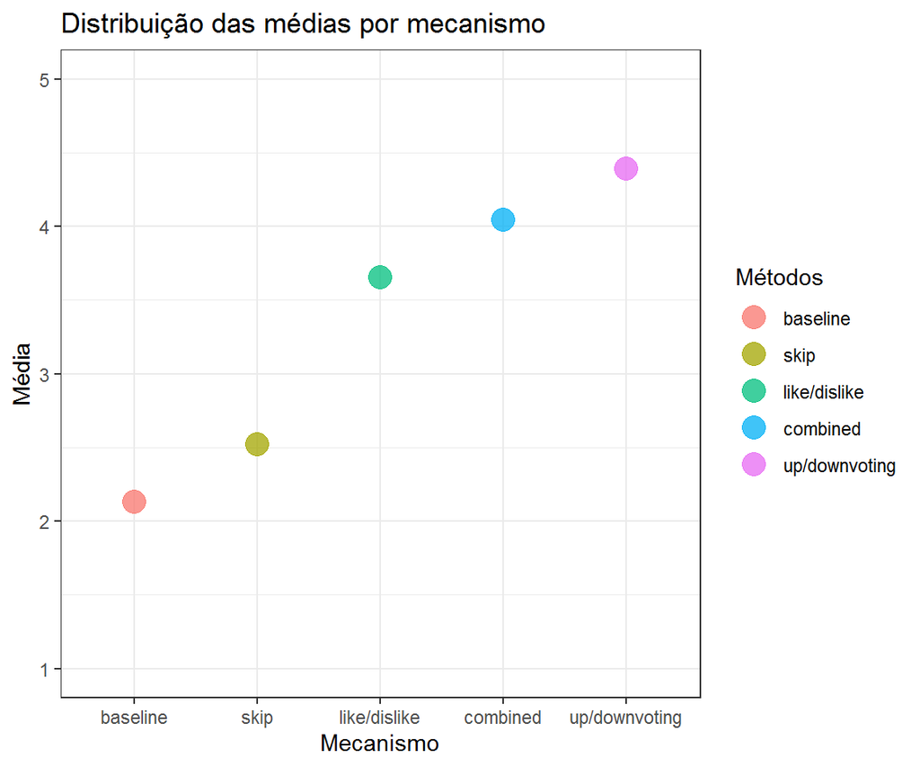

Calculando a média por mecanismo é possível verificar que para os mecanismos de up/downvoting e combined são os que melhor apresentam maior média, com destaque para o up/downvoting.

```
## [1] 2.130435 3.652174 2.521739 4.043478 4.391304
```

Para fazer uma análise mais adequada podemos calcular o intervalos de confiança (IC) e o testes de hipóteses (TH) para comprovar que realmente esses dois mecanismos representam de maneira fiel a representação entre os outros mecanismos.